# Git Practice with RStudio

Your name here

## Introduction

As a group, pick one or two of the following questions to explore. Each question has at leat 2 sub-questions.

After you answer each sub-question, save and commit your changes (I recommend knitting at this point to make sure your code runs). At the end of each larger question, push your changes to GitHub and verify that your project on GitHub updated.

You do not need to correctly solve every part of the question; the goal is to practice workflow with RStudio + GitHub.

# Questions

## I. Data Joins Exercise

Superpowers challenge problem: this is a question that combines skills from chapter 5 (data transformation) and chapter 13 (joins).

Between DC and Marvel, which publisher’s heroes tend to have more powers? Let’s compare visually and numerically.

To answer this question, you will need to:

#### Question 1

Filter the heroes data to only include Marvel or DC. You can also eliminate the DC version of Captain Marvel.

```r
MorDC <- heroes %>% filter((Publisher=='Marvel Comics' | Publisher=='DC Comics') & (name!='Captain Marvel' | Publisher!='DC Comics'))
```

#### Question 2

Create a new variable called “num_powers” in the powers data set counting the number of powers each character has. (This is tricky; there are multiple ways to approach this. You may want to play with the rowSums() function, or see Boern’s answer [here](https://stackoverflow.com/questions/28873057/sum-across-multiple-columns-with-dplyr)).

```r
PowersWithSum <- cbind(powers, 'num_powers' = powers %>% select(-hero_names) %>% rowSums(na.rm=TRUE))
```

#### Question 3

Join the two data sets together by character name and only keep name, publisher, and number of powers

```r
#Remove NA values because Agent 13 (and possible others) are listed in heroes but not powers. Group by publisher here because it will take less code than doing it in the next step.
PowByPub <- left_join(MorDC, PowersWithSum, by=c('name'='hero_names')) %>% select(name, Publisher, num_powers) %>% filter(!is.na(num_powers)) %>% group_by(Publisher)
```

#### Question 4

Group by publisher and look at the distributions of numbers of powers within each publisher by creating summary tables (min, median, mean, max)

```r
summarise(PowByPub, min(num_powers), median(num_powers), mean(num_powers), max(num_powers))
```

```
## # A tibble: 2 x 5
##   Publisher `min(num_powers~ `median(num_pow~ `mean(num_power~
##   <chr>                <dbl>            <dbl>            <dbl>
## 1 DC Comics                1                8             9.76
## 2 Marvel C~                1                7             9.00
## # ... with 1 more variable: `max(num_powers)` <dbl>
```

#### Question 5

Create a graph such as a histogram or boxplot showing the numbers of powers per character for Marvel vs DC.

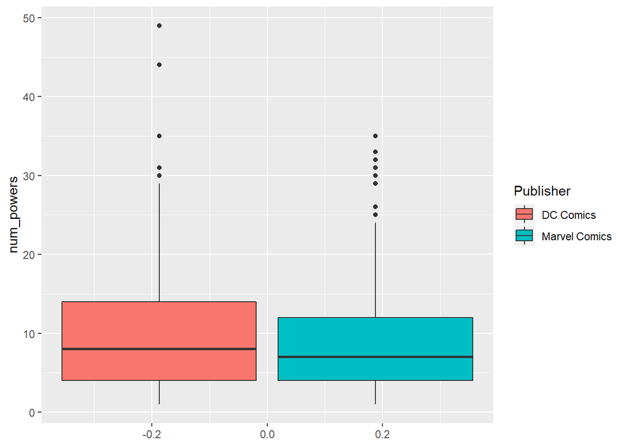

```r
ggplot(data=PowByPub) + geom_boxplot(mapping=aes(y=num_powers, fill=Publisher))
```

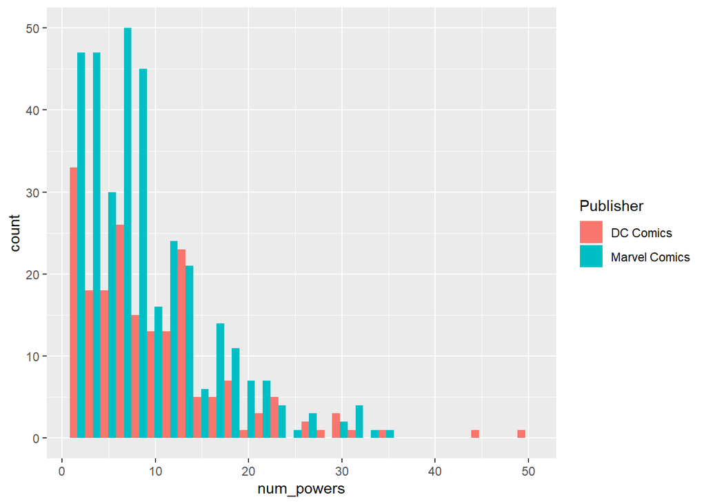

```r
ggplot(data=PowByPub) + geom_histogram(mapping=aes(x=num_powers, fill=Publisher), position='dodge')
```

#### Question 6

Write a couple sentences to compare the distributions and decide if one publisher seems to have characters with more powers overall.

**Your answer:** Marvel has a lower median, mean, and max power count per character than DC according to this caluclation. This indicates that DC characters tend to have more powers overall than Marvel characters.

#### Question 7

Write a couple sentences critiquing this approach. Discuss at least one major problem that prevents our code from actually measuring what we are trying to measure.

## II. Data Transformation Exercise

This is R for Data Science Exercise 5.5.

#### Question 1

1. Currently dep_time and sched_dep_time are convenient to look at, but hard to compute with because they’re not really continuous numbers. Convert them to a more convenient representation of number of minutes since midnight. (Hint: use modulo arithmetic and integer division; this is tricky!)

```r
flights1=mutate(flights, deptime_minutes=floor(dep_time/100)*60+(dep_time-floor(dep_time/100)*100), scheddeptime_minutes=floor(sched_dep_time/100)*60+(sched_dep_time-floor(sched_dep_time/100)*100))
head(select(flights1, dep_time, deptime_minutes, sched_dep_time, scheddeptime_minutes))
```

```
## # A tibble: 6 x 4
##   dep_time deptime_minutes sched_dep_time scheddeptime_minutes
##      <int>           <dbl>          <int>                <dbl>
## 1      517             317            515                  315
## 2      533             333            529                  329
## 3      542             342            540                  340
## 4      544             344            545                  345
## 5      554             354            600                  360
## 6      554             354            558                  358
```

#### Question 2

2. Compare air_time with arr_time - dep_time. What do you expect to see? What do you see? What do you need to do to fix it? You don’t actually need to fix it– just explain how you would. (Hint: you may need to check the [documentation](https://www.transtats.bts.gov/DL_SelectFields.asp?Table_ID=236) for the data)

```r
#First, they are not equal because air_time is in minutes and arr_time and dep_time are in HHMM/HMM.
head(cbind(flights['air_time'], flights['arr_time']-flights['dep_time']))
```

```
##   air_time arr_time
## 1      227      313
## 2      227      317
## 3      160      381
## 4      183      460
## 5      116      258
## 6      150      186
```

```r
#Even adjusting for this, they are not equal. This is most likely because arr_time and dep_time are both in local time (potentially different time zones) but air_time is the actual number of minutes elapsed. However, I would expect a time zone difference to lead to errors in multiples of 60 minutes, which is not the case, so I am not certain.
flights2=mutate(flights1, arrtime_minutes=floor(arr_time/100)*60+(arr_time-floor(arr_time/100)*100))

head(cbind(flights2['air_time'], flights2['arrtime_minutes']-flights2['deptime_minutes']))
```

```
##   air_time arrtime_minutes
## 1      227             193
## 2      227             197
## 3      160             221
## 4      183             260
## 5      116             138
## 6      150             106
```

#### Question 3

3. Compare dep_time, sched_dep_time, and dep_delay. How would you expect those three numbers to be related?

```r
#I would expect that dep_delay=dep_time-sched_dep_time, which appears to be true
select(flights, dep_time, sched_dep_time, dep_delay)
```

```
## # A tibble: 336,776 x 3
##    dep_time sched_dep_time dep_delay
##       <int>          <int>     <dbl>
##  1      517            515         2
##  2      533            529         4
##  3      542            540         2
##  4      544            545        -1
##  5      554            600        -6
##  6      554            558        -4
##  7      555            600        -5
##  8      557            600        -3
##  9      557            600        -3
## 10      558            600        -2
## # ... with 336,766 more rows
```

#### Question 4

4. Find the 10 most delayed flights using a ranking function. How do you want to handle ties? Carefully read the documentation for min_rank().

```r
#Assuming most delayed departure. It would be trivial to modify to arrival delay or departure delay + arrival delay.
#Ties handled as same rank, skipping subsequent ranks according to number of tied values, e.g., 1st, 2nd, 2nd, 4th, ....
flights %>% mutate(DelayRank = min_rank(desc(dep_delay))) %>% arrange(DelayRank) %>% select(DelayRank, dep_delay) %>% head(10)
```

```
## # A tibble: 10 x 2
##    DelayRank dep_delay
##        <int>     <dbl>
##  1         1      1301
##  2         2      1137
##  3         3      1126
##  4         4      1014
##  5         5      1005
##  6         6       960
##  7         7       911
##  8         8       899
##  9         9       898
## 10        10       896
```

## III. Data Visualization Exercise

Let’s make maps using ggplot and the `HappyPlanetIndex` data.

#### Question 1

1. See if you can adapt the textbook code for the map of New Zealand in section 3.9 to display a map of the world instead. Color the continents forest green with a lemon chiffon outline. Check out [this overview](http://www.stat.columbia.edu/~tzheng/files/Rcolor.pdf) of colors in R if you want to play with the coloring a bit.

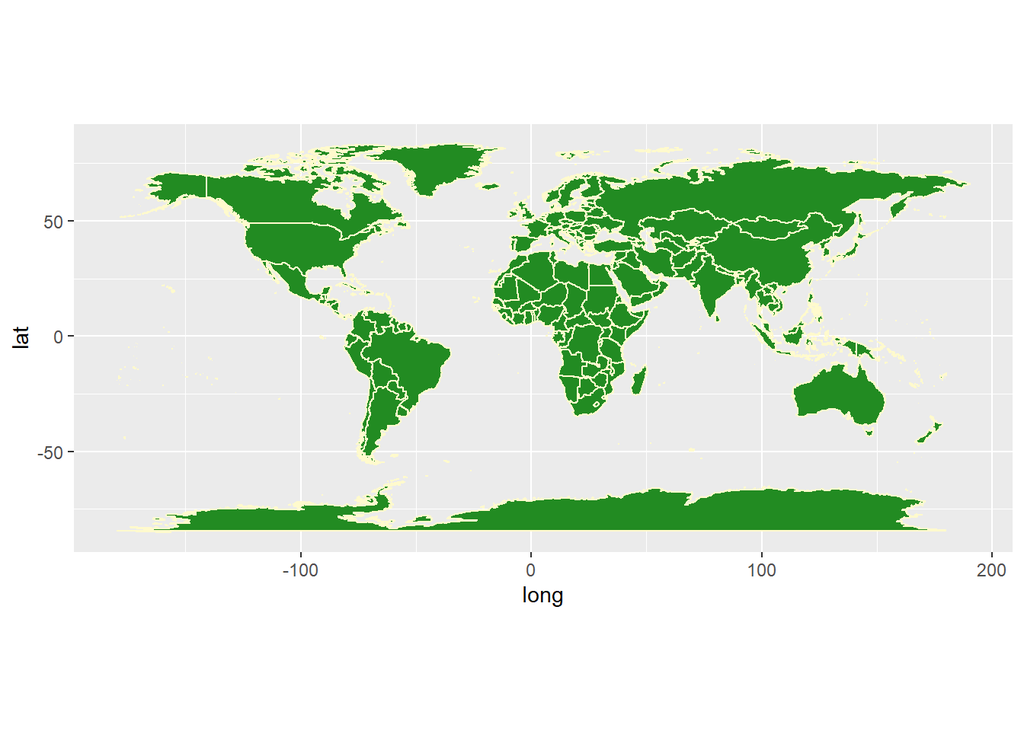

```r
world=map_data("world")

ggplot(world, aes(long, lat, group = group)) +
  geom_polygon(fill = "forest green", colour = "lemon chiffon") +
  coord_quickmap()
```

#### Question 2

2. Create a choropleth map of world happiness using `HappyPlanetIndex` data. In other words, create a world map, but instead of having every country the same color, apply different colors based on the happiness level of that country (using the Happiness variable in the HappyPlanetIndex data set). [This guide](https://www.datanovia.com/en/blog/how-to-create-a-map-using-ggplot2/) can get you started.

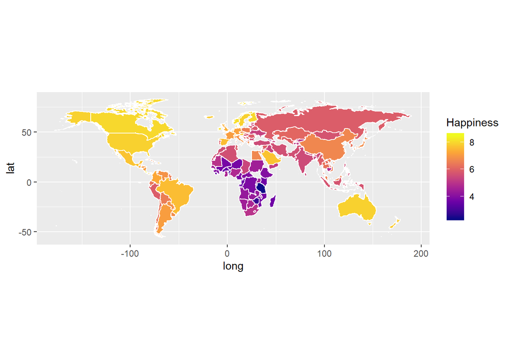

```r
world=map_data("world")
#Since HPI and world have different names for some countries, we must rename
#those countries in one of them to make them appear
world <- mutate(world, FixedReg=recode(region,
                                             'USA'='United States of America',
                                             'Democratic Republic of the Congo'='Congo, Dem. Rep. of the',
                                             'Republic of Congo'='Congo', #assuming this is true, but I'm not exactly familiar with the politics of Congo
                                             'Myanmar'='Burma',
                                             'North Korea'='Korea',
                                             'South Korea'='Korea',
                                             'Trinidad'='Trinidad and Tobago',
                                             'Tobago'='Trinidad and Tobago',
                                             'UK'='United Kingdom'))
#Hong Kong is part of China, so one of the data sets does not have data for it
#and the other does. Leaving it alone. Libya and some other countries don't
#exist in HappyMap (even if they do in world, as Libya does), so there are no
#happiness data for these and I can't force them to appear.
HappyMap=left_join(HappyPlanetIndex,world,by=c('Country'='FixedReg'))
ggplot(HappyMap, aes(long, lat, group = group))+geom_polygon(aes(fill = Happiness), color = "white")+scale_fill_viridis_c(option = "C")+coord_quickmap()
```

## IV. Data Transformation Discussion Exercises:

#### DE2. All about NA:

Play around with NA values. What happens if you find the mean of a variable that has missing data? How can you avoid this? Discuss the pros and cons of each approach, and why you think R takes the default setting that it does.

Then dig deeper: Try to predict the results of each of the following pieces of code, and discuss whether the results make sense based on your previous thoughts about NA’s.

```r
NA^0

NA | TRUE

NA & FALSE

NA | FALSE

NA * 0

NA == NA

NA^FALSE | NA^TRUE

NA^FALSE & NA^TRUE
```

#### DE 3: Filter vs [ ]

We learned in week 1 and 2 to subset a vector or data frame using [ ]. This is very similar to filter, but the syntax is different. For instance, to select the flights which traveled the maximum distance, we could use:

```r
maxdist <- max(flights$distance, na.rm = TRUE)

flights[flights$distance == maxdist,]
```

```
## # A tibble: 342 x 19
##     year month   day dep_time sched_dep_time dep_delay arr_time
##    <int> <int> <int>    <int>          <int>     <dbl>    <int>
##  1  2013     1     1      857            900        -3     1516
##  2  2013     1     2      909            900         9     1525
##  3  2013     1     3      914            900        14     1504
##  4  2013     1     4      900            900         0     1516
##  5  2013     1     5      858            900        -2     1519
##  6  2013     1     6     1019            900        79     1558
##  7  2013     1     7     1042            900       102     1620
##  8  2013     1     8      901            900         1     1504
##  9  2013     1     9      641            900      1301     1242
## 10  2013     1    10      859            900        -1     1449
## # ... with 332 more rows, and 12 more variables: sched_arr_time <int>,
## #   arr_delay <dbl>, carrier <chr>, flight <int>, tailnum <chr>,
## #   origin <chr>, dest <chr>, air_time <dbl>, distance <dbl>, hour <dbl>,
## #   minute <dbl>, time_hour <dttm>
```

Compare this approach to using filter. Which do you like better? Which is clearer? Consider also the following example, which may be relevant:

(You may need to change the name of the temperature varaible below if you already completed BE3.)

```r
maxtemp <- max(chicago$tmpd, na.rm = TRUE)

chicago[chicago$tmpd == maxtemp,]
```

```
##      city tmpd   dptp       date pm25tmean2 pm10tmean2 o3tmean2 no2tmean2
## 3116 chic   92 76.375 1995-07-13         NA       92.5 58.54952  27.31775
## NA   <NA>   NA     NA       <NA>         NA         NA       NA        NA
```

All of these were done in a google doc, so I’m not going to rewrite it here.